# Regression Model

Luiz Bergo

24/11/2019

## Summary

This is a project assignment as per request to complete the Regression Model course from Johns Hopkins University powered by Coursera. The main idea is to analyse the mtcars dataset provided in R Packages and answer the question that raised:

**“Is an automatic or manual transmission better for MPG?”**

Also is asked to “Quantify the MPG difference between automatic and manual transmissions”.

At the following ssesions the data is discussed to properly answer the question.

## Exploratory Data Analysis

The **mtcars** dataset is composed for 32 samples and 11 variables.

```r
data("mtcars")
head(mtcars)
```

```
##                    mpg cyl disp  hp drat    wt  qsec vs am gear carb
## Mazda RX4         21.0   6  160 110 3.90 2.620 16.46  0  1    4    4
## Mazda RX4 Wag     21.0   6  160 110 3.90 2.875 17.02  0  1    4    4
## Datsun 710        22.8   4  108  93 3.85 2.320 18.61  1  1    4    1
## Hornet 4 Drive    21.4   6  258 110 3.08 3.215 19.44  1  0    3    1
## Hornet Sportabout 18.7   8  360 175 3.15 3.440 17.02  0  0    3    2
## Valiant           18.1   6  225 105 2.76 3.460 20.22  1  0    3    1
```

```r
dim(mtcars)
```

```
## [1] 32 11
```

The idea is to predict the influence of type of transmission (automatic or manual) in the fuel consumption **mpg** (Miles/(US) gallon). The remaining variable are descripted as follow:

**cyl** - Number of cylinders  
**disp** - Displacement (cu.in.)  
**hp** - Gross horsepower  
**drat** - Rear axle ratio  
**wt** - Weight (1000 lbs)  
**qsec** - 1/4 mile time  
**vs** - Engine (0 = V-shaped, 1 = straight)  
**am** - Transmission (0 = automatic, 1 = manual)  
**gear** - Number of forward gears  
**carb** - Number of carburetors

Correlation of outcome with possible predictors:

```r
cor(mtcars)[1,]
```

```
##        mpg        cyl       disp         hp       drat         wt
##  1.0000000 -0.8521620 -0.8475514 -0.7761684  0.6811719 -0.8676594
##       qsec         vs         am       gear       carb
##  0.4186840  0.6640389  0.5998324  0.4802848 -0.5509251
```

A comparison between the variables are depicted in the **Appendix**.

## Model Adjustment

The first idea is to evaluate fuel consumption acording to the transmisison.

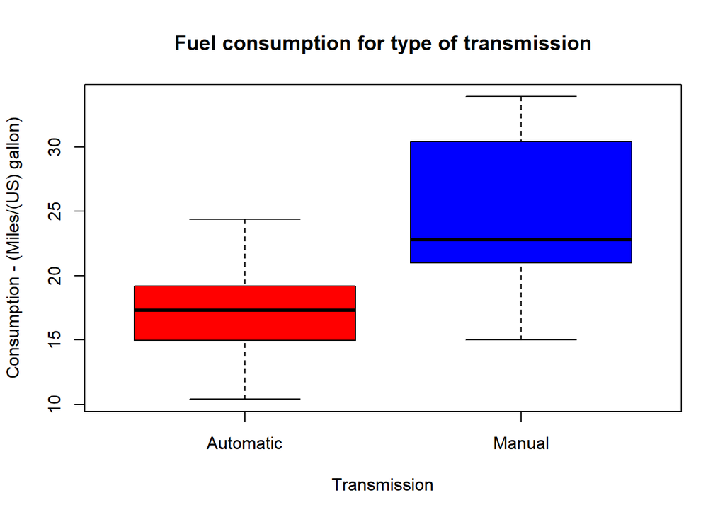

```r
cars <- mtcars
cars$am <- as.factor(cars$am)
levels(cars$am) <- c("Automatic", "Manual")

boxplot(mpg~am, data = cars, main = "Fuel consumption for type of transmission",
        col=c("red","blue"), xlab = "Transmission",ylab = "Consumption - (Miles/(US) gallon)")
```

```r
fit0 <- lm(mpg ~ factor(am), data=cars)
tcritical <- qt(0.975, fit0$df)
print(paste("Critical t value at 95% of confidence to reject null hypothesis :", round(tcritical, 3)))
```

```
## [1] "Critical t value at 95% of confidence to reject null hypothesis : 2.042"
```

```r
summary(fit0)
```

```
##
## Call:
## lm(formula = mpg ~ factor(am), data = cars)
##
## Residuals:
##     Min      1Q  Median      3Q     Max
## -9.3923 -3.0923 -0.2974  3.2439  9.5077
##
## Coefficients:
##                  Estimate Std. Error t value Pr(>|t|)
## (Intercept)        17.147      1.125  15.247 1.13e-15 ***
## factor(am)Manual    7.245      1.764   4.106 0.000285 ***
## ---
## Signif. codes:  0 '***' 0.001 '**' 0.01 '*' 0.05 '.' 0.1 ' ' 1
##
## Residual standard error: 4.902 on 30 degrees of freedom
## Multiple R-squared:  0.3598, Adjusted R-squared:  0.3385
## F-statistic: 16.86 on 1 and 30 DF,  p-value: 0.000285
```

The t-values for coeficients are greater than $t_c$ so it is validy assume some correlation between the variables and transmission explain about **34%** of variance at fuel comsuption. This lead us to interpret that **manual transmission cars** tend to consume less than **automatic**.

Considering that just **34%** of variation is explained for this model some other variables may be included for a better understandig. Such variation can either be observed in the plot of residuals.

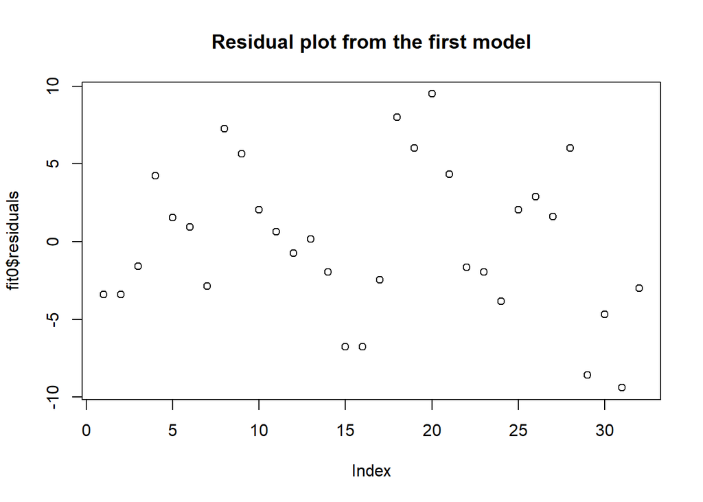

```r
plot(fit0$residuals, main = "Residual plot from the first model")
```

The first approach is to evaluate a linear fit including all the variables available as predictors.

```r
fitall <- lm(mpg ~ ., data=cars)
summary(fitall)
```

```
##
## Call:
## lm(formula = mpg ~ ., data = cars)
##
## Residuals:
##     Min      1Q  Median      3Q     Max
## -3.4506 -1.6044 -0.1196  1.2193  4.6271
##
## Coefficients:
##             Estimate Std. Error t value Pr(>|t|)
## (Intercept) 12.30337   18.71788   0.657   0.5181
## cyl         -0.11144    1.04502  -0.107   0.9161
## disp         0.01334    0.01786   0.747   0.4635
## hp          -0.02148    0.02177  -0.987   0.3350
## drat         0.78711    1.63537   0.481   0.6353
## wt          -3.71530    1.89441  -1.961   0.0633 .
## qsec         0.82104    0.73084   1.123   0.2739
## vs           0.31776    2.10451   0.151   0.8814
## amManual     2.52023    2.05665   1.225   0.2340
## gear         0.65541    1.49326   0.439   0.6652
## carb        -0.19942    0.82875  -0.241   0.8122
## ---
## Signif. codes:  0 '***' 0.001 '**' 0.01 '*' 0.05 '.' 0.1 ' ' 1
##
## Residual standard error: 2.65 on 21 degrees of freedom
## Multiple R-squared:  0.869,  Adjusted R-squared:  0.8066
## F-statistic: 13.93 on 10 and 21 DF,  p-value: 3.793e-07
```

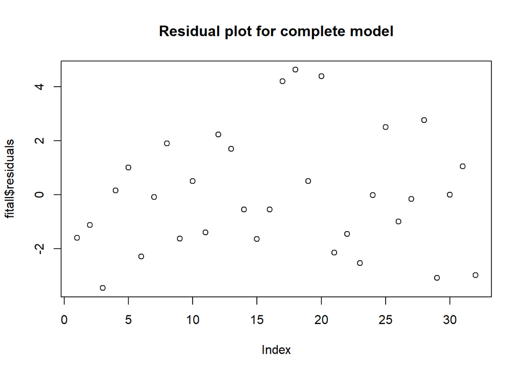

```r
plot(fitall$residuals, main = "Residual plot for complete model")
```

The model including all variables change has a better result than the first model with just **am** (transmition) as a predictor with about **81%** of variance explained.

Although it is possible to observe a high variation inflation, suggesting the model can be simplified.

```r
vif(fitall)
```

```
##       cyl      disp        hp      drat        wt      qsec        vs
## 15.373833 21.620241  9.832037  3.374620 15.164887  7.527958  4.965873
##        am      gear      carb
##  4.648487  5.357452  7.908747
```

Observing the plot and correlation between variables depicted at the *Appendix* it is possible to propose new fits observing that onde more correlated to mpg.

```r
fit1 <- lm(mpg ~ factor(am) + wt, data=cars)
vif(fit1)
```

```
## factor(am)         wt
##   1.921413   1.921413
```

```r
summary(fit1)$adj.r.squared
```

```
## [1] 0.7357889
```

With this model **74%** of variance is explained.

To improve the model the **hp** predictor was included and the variance explained is **82%**, better than the model with all the predictors.

```r
fit2 <- lm(mpg ~ factor(am) + wt + hp, data=cars)
vif(fit2)
```

```
## factor(am)         wt         hp
##   2.271082   3.774838   2.088124
```

```r
summary(fit2)$adj.r.squared
```

```
## [1] 0.8227357
```

Other predictors were tested aiming increase in the adjusted R square factor, and the final model includes **am**, **wt**, **hp** and **cyl** as predictors and the variance explained is **83%**.

A caveat is the variance inflation observed in the ***hp** predictor since it is very correlated to **cyl** predictor.

```r
fit3 <- lm(mpg ~ factor(am) + wt + hp + cyl, data=cars)
vif(fit3)
```

```
## factor(am)         wt         hp        cyl
##   2.546159   3.988305   4.310029   5.333685
```

```r
summary(fit3)$adj.r.squared
```

```
## [1] 0.8266657
```

It´s worthy to note the residual plot is quite near from that obtained using all the predictors.

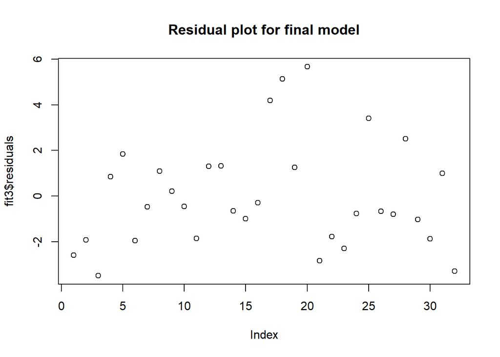

```r
plot(fit3$residuals, main = "Residual plot for final model")
```

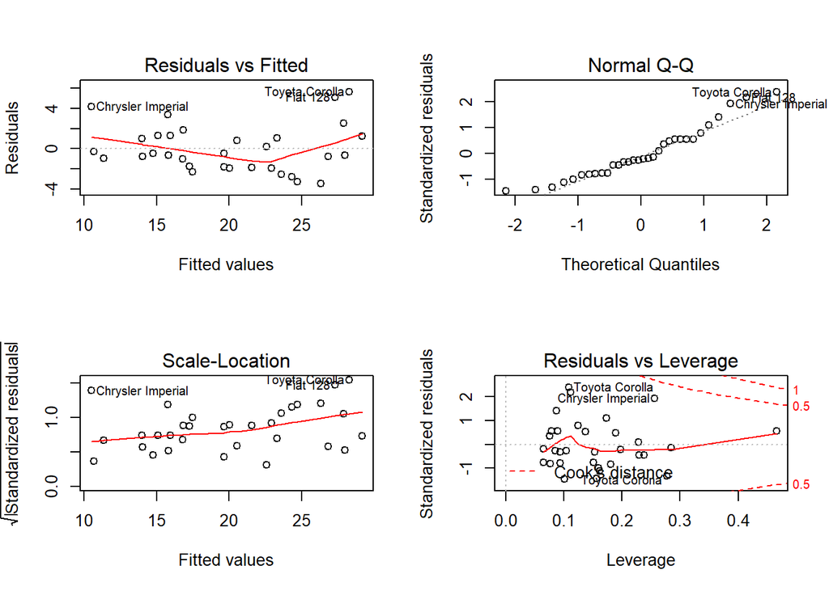

```r
par(mfrow = c(2,2))
plot(fit3)
```

The coeficients for the final model are:

```r
summary(fit3)$coef
```

```
##                     Estimate Std. Error   t value     Pr(>|t|)
## (Intercept)      36.14653575 3.10478079 11.642218 4.944804e-12
## factor(am)Manual  1.47804771 1.44114927  1.025603 3.141799e-01
## wt               -2.60648071 0.91983749 -2.833632 8.603218e-03
## hp               -0.02495106 0.01364614 -1.828433 7.855337e-02
## cyl              -0.74515702 0.58278741 -1.278609 2.119166e-01
```

## Conclusion

```r
confint(fit3)
```

```
##                        2.5 %       97.5 %
## (Intercept)      29.77605177 42.517019733
## factor(am)Manual -1.47894635  4.435041763
## wt               -4.49383134 -0.719130075
## hp               -0.05295064  0.003048517
## cyl              -1.94093802  0.450623969
```

## Apendix

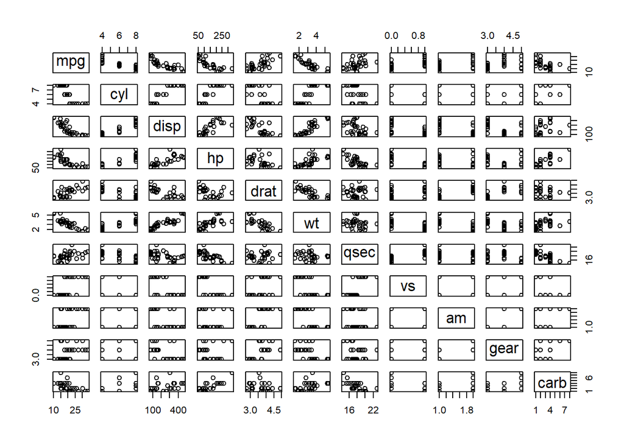

```r
pairs(cars)
```